# Using Random Forest in R for Butterfly Fauna Distribution in Pakistan

by M. Gimpel | 15.01.2020

# 1 Theory of a Random Forest

The **Random Forest** (or *Random Decision Forest*) is a model in the area of machine learning. It is an extension of Classification and Regression Trees (CART). A Random Forest grows many classification trees and puts the input data down each of the trees in the forest. Each tree gives a classification, and we say the tree “votes” for that class. The forest chooses the classification having the most votes over all the trees in the forest.

## 1.1 What is a Classification Tree?

#### Warning!

It is assumed that the user knows about the concept of single classification trees. If not, this should be studied independently beforehand. Further Information can be found on [Wikipedia](https://en.wikipedia.org/wiki/Decision_tree_learning).

Quick Reminder:

Let’s go quickly over decision trees as they are the building blocks of the random forest model. Fortunately, they are pretty intuitive and most people have used them in their lives, knowingly or not.

Decision trees build classification or regression models in form of a tree structure. The model breaks down a dataset into smaller and smaller subsets while at the same time incrementally developing an associated decision tree. The final result is a tree with decision (internal) nodes and leaf nodes (see image below). Furthermore, a branch that splits left is called “left daughter” and one that splits right “right daughter”.

Let’s consider the following example in which we use a decision tree to decide upon an activity on a particular day:

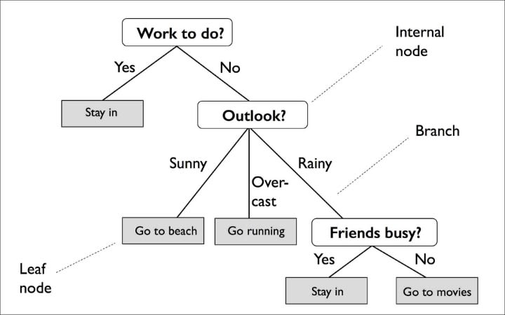

Img. 1: Example for a simple everyday decision tree by [nexttech](https://dev.to/nexttech/classification-and-regression-analysis-with-decision-trees-jgp).

Applied to a real life scenario our data will not be this clean but the logic that a decision tree employs remains the same.

### 1.1.1 The Difference between a Classification Tree and a Random Forest

A Random Forest, like its name implies, consists of a large number of individual decision trees that operate as an ensemble. Each individual tree in the Random Forest generates a class prediction (vote) and the class with the most votes becomes our model’s prediction over all the trees in the forest (see image below, hover to enlarge).

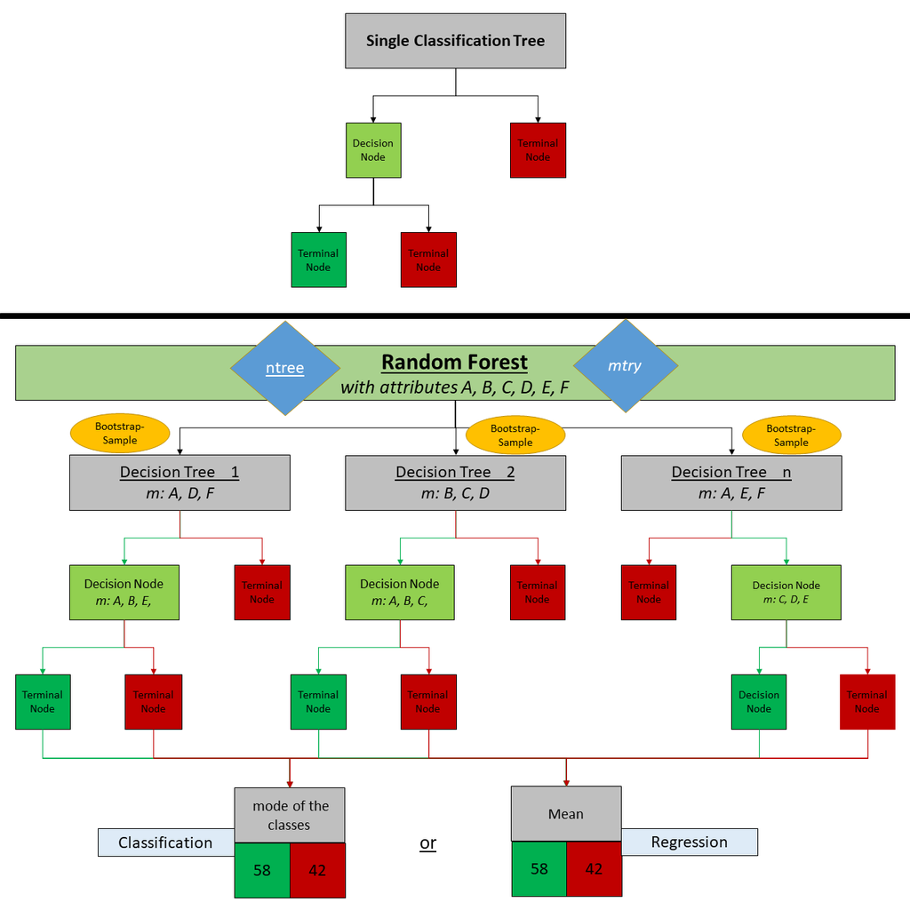

Img. 2: Comparison between Decision Trees and Random Forest.

The number of trees is determined via the parameter “ntree” and the number of randomly selected attributes via “mtry” (blue squares). In this example mtry is three and ntree is n.

These subsets of randomly picked attributes are also known as bootstrap samples. This is important to understand how the model verifies itself through the OOB Error Rate which makes crossvalidating unnecessary.

The function “randomForest” can take a formula or, in two separate arguments, a data frame with **predictor variables** (previously called “attributes”), and a vector with the result. If the result variable is a factor (categorical), randomForest will do a classification, otherwise it will do a regression. Whereas with species distribution modeling we are often interested in classification (species is present or not).